# Rogers_HW3

Alex Rogers

Hi Nico, sorry you have to read all this mess. This shit is so hard for me.

```r
library(tidyverse)
deck <- tibble(
  # tibble is a more flexible data.frame
  card = rep(
    c("ace",
      "deuce",
      "three",
      "four",
      "five",
      "six",
      "seven",
      "eight",
      "nine",
      "ten",
      "jack",
      "queen",
      "king"
    ),4),
  suit =
    rep(c(
      "diamonds",
      "hearts",
      "clubs",
      "spades"),
        each = 13),
  color = rep(c("red",
                "black"),
              each = 26)
)

glimpse(deck)
```

```
## Rows: 52
## Columns: 3
## $ card  <chr> "ace", "deuce", "three", "four", "five", "six", "seven", "eight"~
## $ suit  <chr> "diamonds", "diamonds", "diamonds", "diamonds", "diamonds", "dia~
## $ color <chr> "red", "red", "red", "red", "red", "red", "red", "red", "red", "~
```

```r
pr_black <- deck %>%
  filter(color == "black") %>%
  nrow()/nrow(deck)

pr_ace <- deck %>%
  filter(card == "ace") %>%
  nrow()/nrow(deck)

pr_black_and_ace <- deck %>%
  filter(card == "ace" & color == "black") %>%
  nrow()/nrow(deck)

pr_black + pr_ace - pr_black_and_ace
```

```
## [1] 0.5384615
```

### Question 1

```r
pr_black * pr_black
```

```
## [1] 0.25
```

This seems logical to me, since we only have two options in each event, it’s like flipping a coin twice.

Part 2: Probability of getting one king or one ace: $king \cup ace$. Using naive probability this is number of aces or kings (8) / total number of cards (52)

```r
pr_ace_or_king <-
deck |>
filter(card == "ace" | card == "king")
nrow(pr_ace_or_king)/nrow(deck)
```

```
## [1] 0.1538462
```

Part 3: Probability of getting two aces in two draws with replacement: 4/52 * 4/52

```r
pr_ace <- deck |>
  filter(card == "ace") |>
nrow()/nrow(deck)
  pr_ace * pr_ace
```

```
## [1] 0.00591716
```

### Question 2

```r
sample_n(deck, size =5, replace = FALSE)
```

```
## # A tibble: 5 x 3
##   card  suit     color
##   <chr> <chr>    <chr>
## 1 ten   hearts   red
## 2 three clubs    black
## 3 ace   diamonds red
## 4 ten   clubs    black
## 5 ten   spades   black
```

```r
sample_n(deck, size =5, replace = FALSE)
```

```
## # A tibble: 5 x 3
##   card  suit     color
##   <chr> <chr>    <chr>
## 1 jack  spades   black
## 2 three diamonds red
## 3 ten   spades   black
## 4 eight hearts   red
## 5 nine  clubs    black
```

```r
sample_n(deck, size =5, replace = FALSE)
```

```
## # A tibble: 5 x 3
##   card  suit     color
##   <chr> <chr>    <chr>
## 1 deuce diamonds red
## 2 deuce clubs    black
## 3 six   clubs    black
## 4 seven hearts   red
## 5 eight diamonds red
```

```r
sample_n(deck, size =5, replace = FALSE)
```

```
## # A tibble: 5 x 3
##   card  suit     color
##   <chr> <chr>    <chr>
## 1 ace   spades   black
## 2 seven diamonds red
## 3 four  hearts   red
## 4 queen hearts   red
## 5 four  clubs    black
```

```r
sample_n(deck, size =5, replace = FALSE)
```

```
## # A tibble: 5 x 3
##   card  suit   color
##   <chr> <chr>  <chr>
## 1 five  spades black
## 2 four  clubs  black
## 3 deuce hearts red
## 4 king  spades black
## 5 six   hearts red
```

What is the total number of different hands you can draw in poker? This is asking us to do (I think) 52 choose 5 $\binom{52}{5}$

By googling I found that there is a function in the base R library that does this

(turns out I didn’t need to google this, I just needed to finish reading the chapter)

```r
choose(52, 5)
```

```
## [1] 2598960
```

### Question 3

The probability that each suit is represented in a hand (getting 1 card from each suit, with one suit showing up twice)

```r
pr_hearts <- deck |>
  filter(suit == "hearts")
nrow(pr_hearts)/nrow(deck)
```

```
## [1] 0.25
```

```r
pr_spades <- deck |>
  filter(suit == "spades")
nrow(pr_spades)/nrow(deck)
```

```
## [1] 0.25
```

```r
pr_diamonds <- deck |>
  filter(suit == "diamonds")
nrow(pr_diamonds)/nrow(deck)
```

```
## [1] 0.25
```

```r
pr_clubs <- deck |>
  filter(suit == "clubs")
nrow(pr_clubs)/nrow(deck)
```

```
## [1] 0.25
```

I’m not sure what I was going for here but this was not a helpful direction, I’m saving the code and moving on to a different method.

I’m using the full house in poker example (1.4.20) from Blitztein and Hwang as a guide here.

4 Suits, 1 of each 3 times, 1 of the same 2 times (without replacement.

```r
# this is a syntactical nightmare.
#(4*(choose(52, 1)* 3*(choose(51, 1) * 2*(choose(50, 1) * 1 *(49, 1))))
```

trying again

```r
(4*choose(4, 1) * 3 * choose(4, 1) * 2 * choose(4, 1) * 1 * choose(4, 2)) / choose(52, 5)
```

```
## [1] 0.003546034
```

That feels like a reasonable probability?

### Question 4

What is the probability of getting at least one ace in a five card hand?

So, the probability of getting one ace in one draw is 4/52.

How do I expand that to drawing 5 cards instead of one?

I think this is similar to the previous question, I understand that I need to use the binomial theorem (I think) but the syntax of trying to do this in R is really throwing me.

Okay, joke’s on me, I hadn’t read the R section of the chapter for this week, if I had done that this all would have been a lot easier.

Double joke’s on me, I’ve read the whole thing and I’m still not getting it.

Probability of getting 1 ace in one 5-card hand:

```r
# I'm trying to approach the problem from a more simple perspective

draws <- (replicate(100, (sample)(52,5)))



# this draws 5 cards 100 times, obviously I would need more (e.g.) 10^4 in order to get a good probability estimate, but I'm trying to keep it simple for now.

#So this gives me the data frame "draws". I want to count how many times a 1,2,3,4 (1:4) appears across the data frame, thus counting how many times an ace was drawn. I can then divide that by the total number of cards drawn and I think that would give me the probability of drawing an ace.

#filter(draws, 5 == "1")

#What I'm trying here is to use the filter function to look at row 5 and show only times when a 5 was drawn, this isn't working. I think I need a  tibble with named rows and columns to do this?

#sample(deck, size = 4)

# I realized I'm basically trying to rebuild a tool I already have, which is the deck tibble from earlier in the hw. but now when I try to sample that I get the error "cannot take sample large than the population when 'replace = FALSE'

#but I'm trying to take a sample of 5 with a population of 52 so I don't get that.

#okay so sample(deck, 1) gives me a tibble with just the colors, sample(deck, 2) gives me a tibble with the colors and the card and so on until sample(deck, 4) gives the previous error. So either my syntax is off or I just can't use sample on this tibble (maybe because it's not intergers?) checking out ?sample

#I've been at this question for a couple hours now, getting discouraged, moving on.
```

Okay I’m gonna try again since I was able to mostly figure out the rest of the homework.

The probability of getting an ace is:

first card: 4/52 second card: 4/51 third card: 4/50 fourth card: 4/49 fifth card: 4/48

This isn’t right though because it’s not 4/51 as the second card if we draw an ace on the first card.

Gonna try following the birthday problem example.

```r
1 - ((52 * 51 * 50 * 49 * 48) / 52^5)
```

```
## [1] 0.1797162
```

So I am using the formula

1 - 52 * 53… (52 - k + 1) / 52^k

I’m worried this is wrong though, 17 % feels low?

### Question 5

Clunky solution:

```r
df <- tibble(
  id   = 1:6,
  name = c('Alice', 'Bob', 'Charlie', 'Diane', 'Fred', 'Jenny')
)

df_pairs <- df %>%
  rename(id1 = id, name1 = name) %>%
  crossing(df %>%
             select(id2 = id, name2 = name)) %>%
  filter(id1 < id2) %>%
  unite(id, id1, id2) %>%
  unite(name, name1, name2)

df_pairs
```

```
## # A tibble: 15 x 2
##    id    name
##    <chr> <chr>
##  1 1_2   Alice_Bob
##  2 1_3   Alice_Charlie
##  3 1_4   Alice_Diane
##  4 1_5   Alice_Fred
##  5 1_6   Alice_Jenny
##  6 2_3   Bob_Charlie
##  7 2_4   Bob_Diane
##  8 2_5   Bob_Fred
##  9 2_6   Bob_Jenny
## 10 3_4   Charlie_Diane
## 11 3_5   Charlie_Fred
## 12 3_6   Charlie_Jenny
## 13 4_5   Diane_Fred
## 14 4_6   Diane_Jenny
## 15 5_6   Fred_Jenny
```

This is a committee or “choose” problem so one way to do this is:

```r
choose(6,2)
```

```
## [1] 15
```

I can verify this by listing out the possible pairs assuming order doesn’t matter.

12 13 14 15 16 23 24 25 26 34 35 36 45 46 56

### Question 6

Removing the line “filter(id1 < id2) %>%” almost does it, but it then allows a person to be the president and vice president, which I assume we don’t want.

Trying something different…

```r
df <- tibble(
  id   = 1:6,
  name = c('Alice', 'Bob', 'Charlie', 'Diane', 'Fred', 'Jenny')
)

df_pairs <- df %>%
  rename(id1 = id, name1 = name) %>%
  crossing(df %>%
             select(id2 = id, name2 = name)) %>%
  filter(id1 != id2) %>%
  unite(id, id1, id2) %>%
  unite(name, name1, name2)

df_pairs
```

```
## # A tibble: 30 x 2
##    id    name
##    <chr> <chr>
##  1 1_2   Alice_Bob
##  2 1_3   Alice_Charlie
##  3 1_4   Alice_Diane
##  4 1_5   Alice_Fred
##  5 1_6   Alice_Jenny
##  6 2_1   Bob_Alice
##  7 2_3   Bob_Charlie
##  8 2_4   Bob_Diane
##  9 2_5   Bob_Fred
## 10 2_6   Bob_Jenny
## # ... with 20 more rows
```

I think I did it by using filter and != (not equal) to only show cases where the two names are not the same (thus ensuring that order does matter)

As for an analytic solution, we could do:

```r
(factorial(6)) / (factorial(6-2) * factorial(2))
```

```
## [1] 15
```

Right so one of these is definitely wrong (possibly both)

I’m looking at the tibble and it makes logical sense to me so I think my factorial code is wrong somehow. I must not be correcting for overcounting properly.

```r
(factorial(6)) / (factorial(6-2))
```

```
## [1] 30
```

Okay, I was using the formula where order didn’t matter.

### Question 7

A fair die:

```r
die <- (1:6)

fair_die <- replicate(1000, sample(die, 1))

fair_die_data <- tibble(x = fair_die)

mean(fair_die)
```

```
## [1] 3.515
```

A loaded die that lands on six 50% of the time

```r
 die <- (1:6)

six_die <- replicate(1000, sample(die, 1, prob = c(.1, .1, .1, .1, .1, .5)))

six_die_data <- tibble(x = six_die)

mean(six_die)
```

```
## [1] 4.408
```

```r
 die <- (1:6)

thirds_die <- replicate(1000, sample(die, 1, prob = c(.1, .1, .1, .1, .3, .3)))

thirds_die_data <- tibble(x = thirds_die)

mean(thirds_die)
```

```
## [1] 4.332
```

Fair die plot:

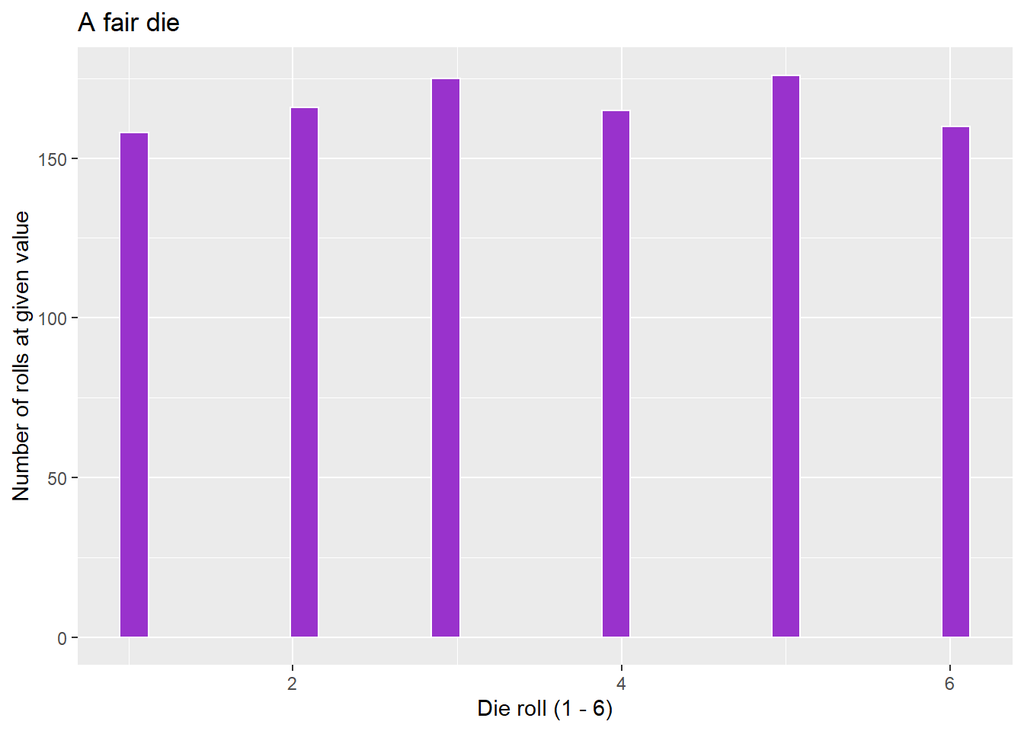

```r
ggplot(fair_die_data, aes(x = x)) +
  geom_histogram(color = "white", fill = "darkorchid") +
  labs(x = "Die roll (1 - 6)", y = "Number of rolls at given value", title = "A fair die")
```

Six Die Plot:

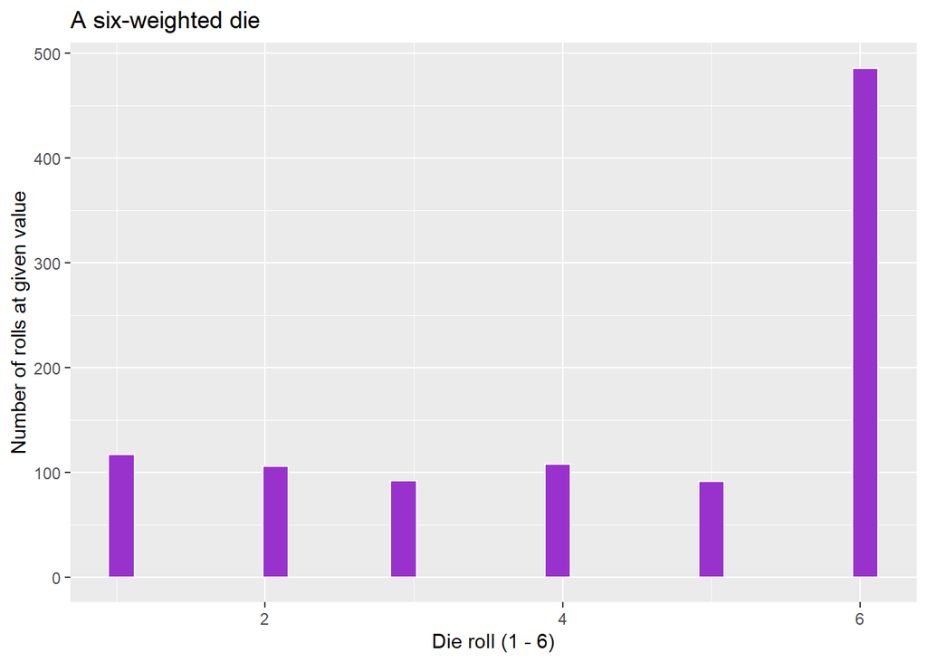

```r
ggplot(six_die_data, aes(x = x)) +
  geom_histogram(color = "white", fill = "darkorchid") +
  labs(x = "Die roll (1 - 6)", y = "Number of rolls at given value", title = "A six-weighted die")
```

Thirds Die Plot:

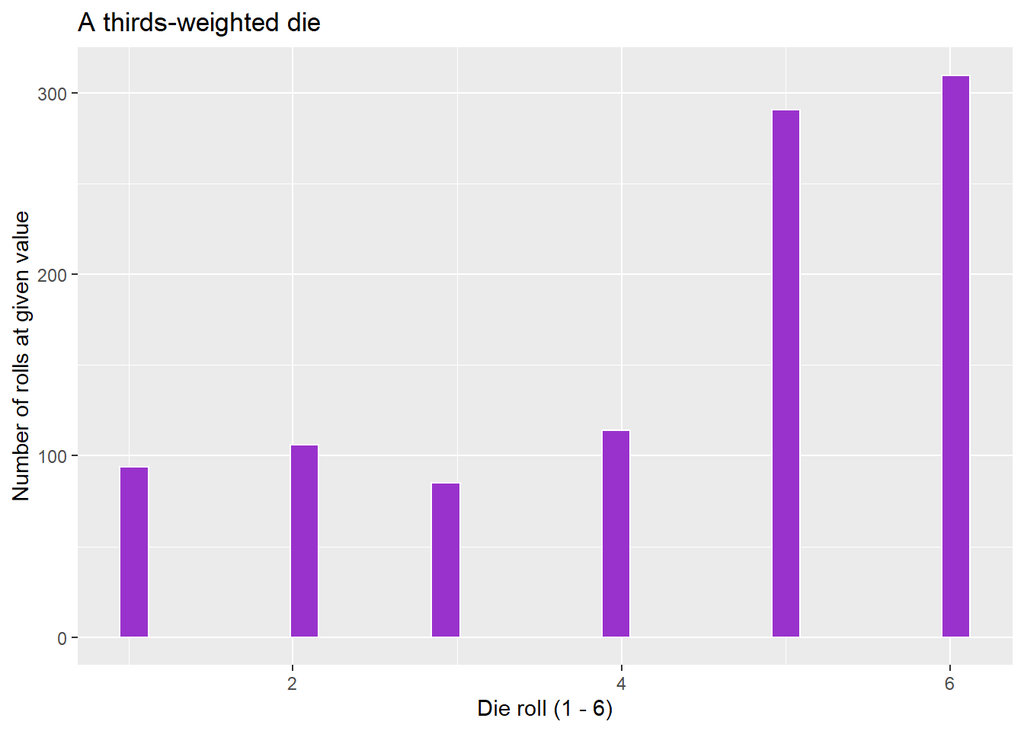

```r
ggplot(thirds_die_data, aes(x = x)) +
  geom_histogram(color = "white", fill = "darkorchid") +
  labs(x = "Die roll (1 - 6)", y = "Number of rolls at given value", title = "A thirds-weighted die")
```

```r
die <- (1:6)

test_die <- replicate(1000, sample(die, 1))

test_die_data <- tibble(Roll_Value = test_die)

mean(test_die)
```

```
## [1] 3.423
```